# Power tests

## Power

Statistical power is the probability of avoiding a Type II error given that the alternative hypothesis \(H_1\) is true.

Remember

- Type I error = false positive, rejecting \(H_0\) when it is true
- Type II error = false negative, not rejecting \(H_0\) when it is false

## The need for power

With little power:

- May not be able to reject \(H_0\) when it is false
- Exaggerate effect size

Lots of power

- Probably can reject \(H_0\) when it is false
- More precise estimates of effect size
- More expensive

Need to do power analysis **before** experiment.

## Components of a power analysis

- Effect size
- Type I error rate (significance level - conventionally set to 0.05)
- Type II error rate (conventionally aim for 0.8)
- Number of observations

Can solve for any of these

Typically want to know how many observations needed.

## One sided Z-test

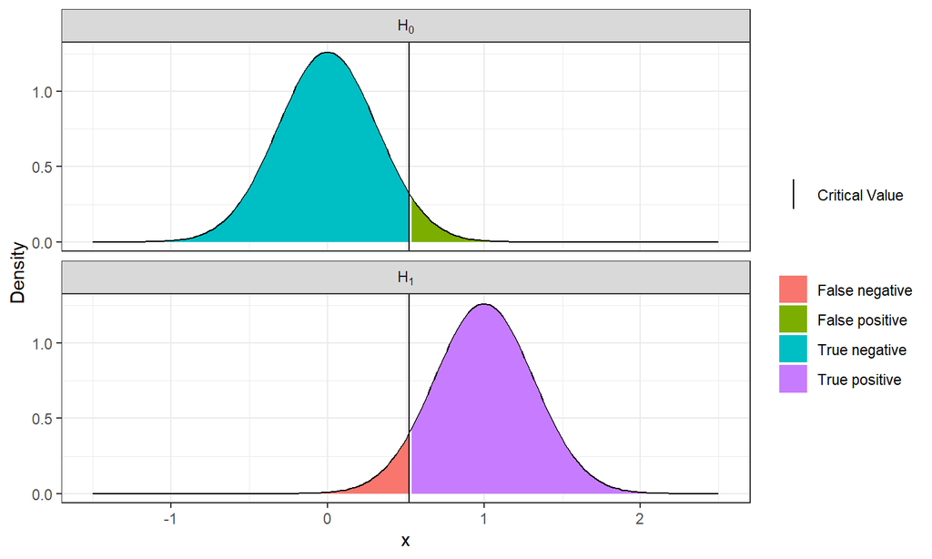

## Analytic power analysis

Some power tests in base R.

- `power.t.test`
- `power.anova.test`
- `power.prop.test`

More in `pwr` package

## Power t test

```r
library("pwr")
pow <- pwr.t.test(d = 0.5, sig.level = 0.05, power = 0.8)
pow
```

```
##
##      Two-sample t test power calculation
##
##               n = 63.76561
##               d = 0.5
##       sig.level = 0.05
##           power = 0.8
##     alternative = two.sided
##
## NOTE: n is number in *each* group
```

Effect size is Cohen’s d \(d = \frac{\mu_1 - \mu_2}{\sigma}\)

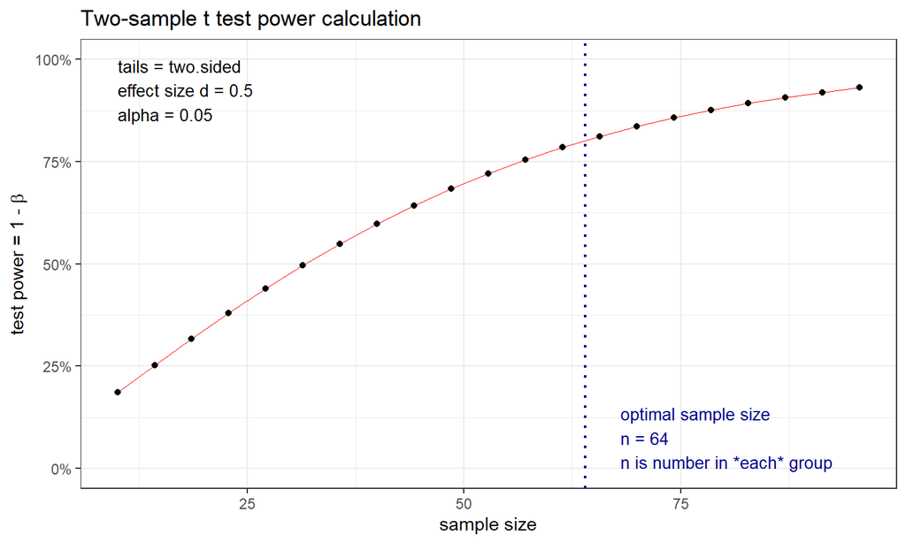

```r
plot(pow)
```

## Power analysis by simulation

Analytical power analysis becomes complex with more complex statistics

- Compex experimental design
- Autocorrelation
- Confounding variables
- Violation of assumptions of models

Simulation always possible

Arnold et al. (2011) Simulation methods to estimate design power:an overview for applied research. http://www.biomedcentral.com/1471-2288/11/94

## General approach

- Simulate your data generating process
- Run statistical test on simulated data
- Repeat many times
- Proportion of runs with significant result is the power.

Trading computer time (cheap) for statistician time (expensive)

## Simulating a t-test

```r
# data info
n <- 30 #number observations in each group
delta <- 1 # difference between means
sd <- 2 # standard deviation

# simulate means
mu <- rep(c(0, delta), each = n)

# add noise
y <- mu + rnorm(length(mu), sd = sd)

## predictor
x <- factor(rep(c("A", "B"), each = n))

# run test
test <- t.test(y ~ x)
```

```r
test
```

```
##
##  Welch Two Sample t-test
##
## data:  y by x
## t = -3.5384, df = 57.983, p-value = 0.0008003
## alternative hypothesis: true difference in means is not equal to 0
## 95 percent confidence interval:
##  -3.001193 -0.832450
## sample estimates:
## mean in group A mean in group B
##      -0.2575734       1.6592483
```

```r
broom::glance(test)
```

```
## # A tibble: 1 x 10
##   estimate estimate1 estimate2 statistic p.value parameter conf.low conf.high
##      <dbl>     <dbl>     <dbl>     <dbl>   <dbl>     <dbl>    <dbl>     <dbl>
## 1    -1.92    -0.258      1.66     -3.54 8.00e-4      58.0    -3.00    -0.832
## # ... with 2 more variables: method <chr>, alternative <chr>
```

## Make a function to re-run

```r
sim_t_test <- function(n, delta, sd, ...){
  # simulate means
  mu <- rep(c(0, delta), each = n)
  # add noise
  y <- mu + rnorm(length(mu), sd = sd)
  ## predictor
  x <- factor(rep(c("A", "B"), each = n))

  # run test
  test <- t.test(y ~ x)
  broom::tidy(test) %>% mutate(n = n, delta = delta, sd = sd)
}

sim_t_test(n = 30, delta = 1, sd = 2)
```

```
## # A tibble: 1 x 13
##   estimate estimate1 estimate2 statistic p.value parameter conf.low conf.high
##      <dbl>     <dbl>     <dbl>     <dbl>   <dbl>     <dbl>    <dbl>     <dbl>
## 1    -1.75    -0.507      1.24     -3.81 3.68e-4      52.0    -2.67    -0.828
## # ... with 5 more variables: method <chr>, alternative <chr>, n <dbl>,
## #   delta <dbl>, sd <dbl>
```

## Repeat many times

```r
nrep = 100

control <- crossing(rep_no = 1:nrep, n = seq(10, 100, 20))

runs <- control %>%
  pmap_df(sim_t_test, delta = 1, sd = 2) %>%
  mutate(sig = p.value <= 0.05)

p <- runs  %>%
  group_by(n) %>%
  summarise(power = mean(sig)) %>%
  ggplot(aes(x = n, y = power)) +
  geom_line() +
  geom_point()
```

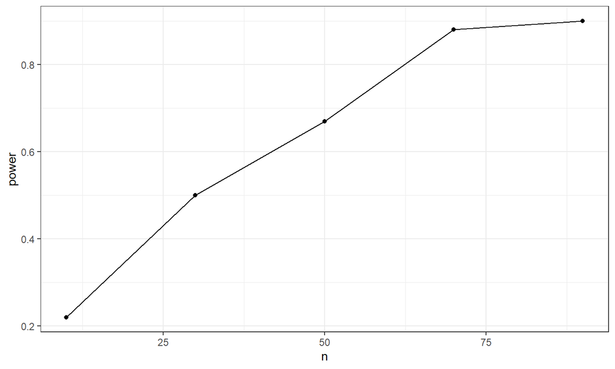

```r
p
```

## Magnitude of Effect

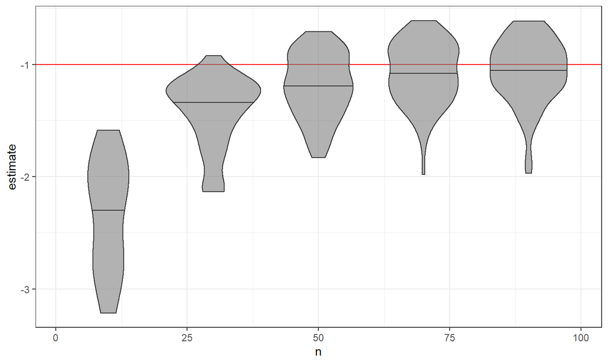